# Data visualisation IV Other Graphs

O Rodriguez de Rivera Ortega, PhD

University of Exeter

## 3D Scatterplot

```r
library(curl)
FI_Murcia <- read.csv(curl("https://raw.githubusercontent.com/orrortega/statistics-natural-resources/main/data/FI_Murcia.csv"))
FI_Murcia_sub = subset(FI_Murcia, Species == c("Castanea sativa", "Fagus sylvatica", "Pinus nigra", "Quercus robur"))
attach(FI_Murcia)
```

Let’s say that we want to plot Height vs. Diameter1 vs. Diameter2 with the National Forest Inventory dataset.

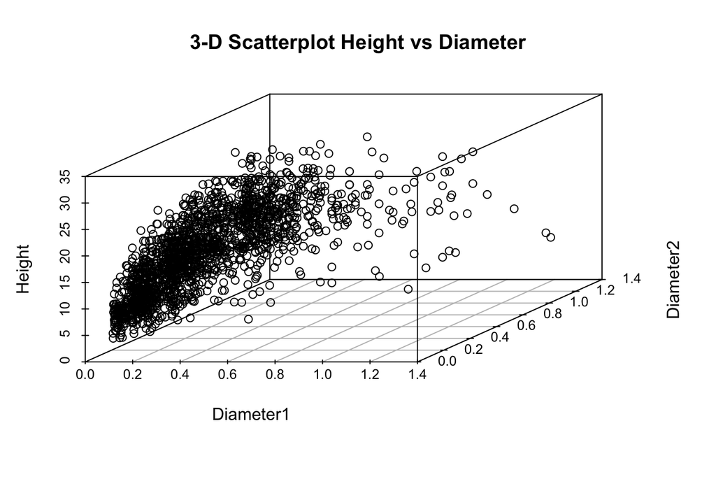

```r
# basic 3-D scatterplot
library(scatterplot3d)
with(FI_Murcia_sub , {
  scatterplot3d(x = Diameter1, y = Diameter2, z = Height,
        main="3-D Scatterplot Height vs Diameter")
})
```

```r
FI_Murcia_sub$Species<-as.character(FI_Murcia_sub$Species)
# create column indicating point color
FI_Murcia_sub$pcolor[FI_Murcia_sub$Species == "Castanea sativa"] <- "red"
FI_Murcia_sub$pcolor[FI_Murcia_sub$Species == "Quercus robur"] <- "blue"
FI_Murcia_sub$pcolor[FI_Murcia_sub$Species == "Fagus sylvatica"] <- "green"
FI_Murcia_sub$pcolor[FI_Murcia_sub$Species == "Pinus nigra"] <- "yellow"
with(FI_Murcia_sub, {
s3d <- scatterplot3d(
x = Diameter1, y = Diameter2, z = Height,
color = pcolor, pch = 19,
main = "3-D Scatterplot Height vs Diameter by species")
# add the legend
legend("topleft", #location
  inset=.05,
cex=1, title="Species",
c("Castanea sativa", "Fagus sylvatica", "Pinus nigra", "Quercus robur"),
fill=c("red", "blue", "green", "yellow"))
})
```

[figure not shown]

## Biplots

A biplot is a specialized graph that attempts to represent the relationship between observations, between variables, and between observations and variables, in a low (usually two) dimensional space.

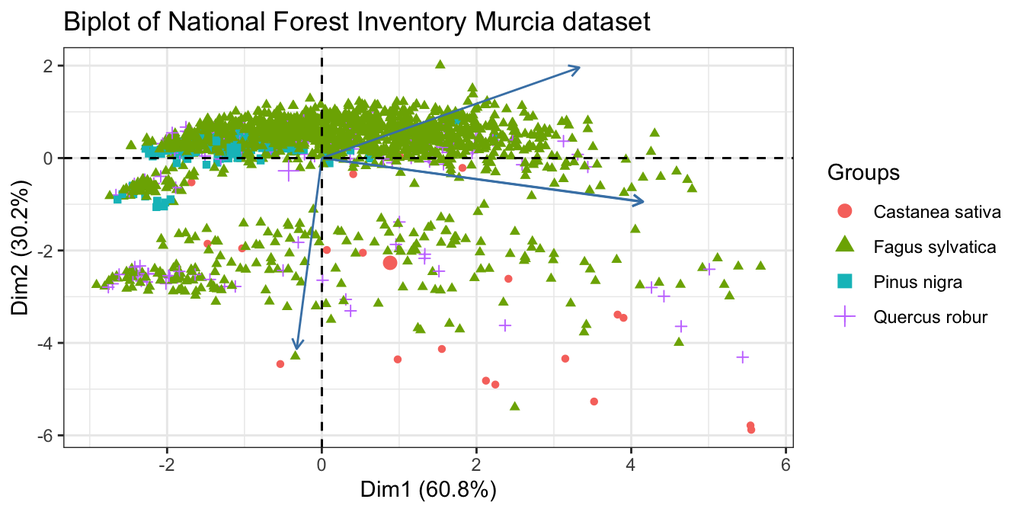

```r
fit <- prcomp(x = FI_Murcia_sub [,-c(1,6)],center = TRUE, scale = TRUE)
library(factoextra) # plot the results
fviz_pca(fit, label="none", habillage=FI_Murcia_sub$Species) + theme_bw() +
  labs(title = "Biplot of National Forest Inventory Murcia dataset")
```

*Dim1* and *Dim2* are the first two principal components - linear combinations of the original p variables.

$PC_{1}$ = $\beta_{10}$ + $\beta_{11}x_1$ + $\beta_{12}x_2$ + … + $\beta_{1p}x_p$

$PC_{2}$ = $\beta_{20}$ + $\beta_{21}x_1$ + $\beta_{22}x_2$ + … + $\beta_{2p}x_p$

The weights of these linear combinations $\beta_{ij}s$ are chosen to maximize the variance accounted for in the original variables. Additionally, the principal components $PC_{s}$ are constrained to be uncorrelated with each other.

In this graph, the first PC accounts for 60% of the variability in the original data. The second PC accounts for 30%. Together, they account for 91% of the variability in the original p = 4 variables.

As you can see, both the observations (Species) and variables (species characteristics) are plotted in the same graph.

- Points represent observations. Smaller distances between points suggest similar values on the original set of variables.
- The vectors (arrows) represent variables. The angle between vectors are proportional to the correlation between the variables. Smaller angles indicate stronger correlations.
- The observations that are farthest along the direction of a variable’s vector, have the highest values on that variable.

**Biplots are only accurate when the percentage of variance accounted for is high. Always check your conclusion with the original data.**

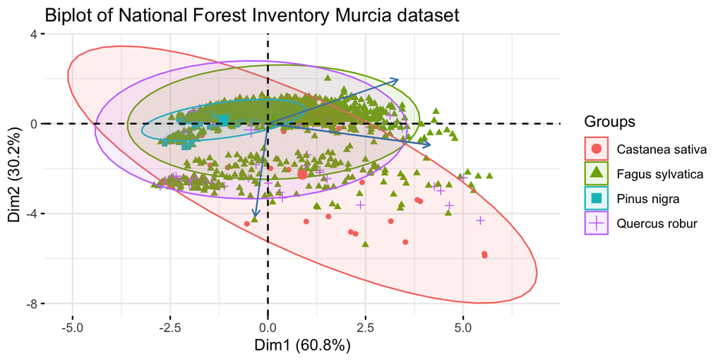

```r
fviz_pca(fit, label="none", habillage=FI_Murcia_sub$Species,
         addEllipses=TRUE, ellipse.level=0.95)+
  labs(title = "Biplot of National Forest Inventory Murcia dataset")
```

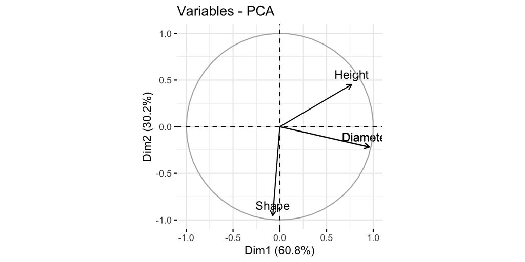

```r
fviz_pca_var(fit)
```

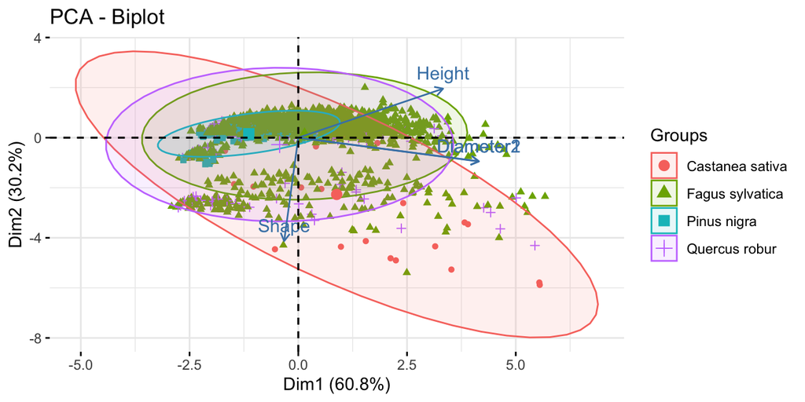

```r
fviz_pca(fit, label="var", habillage=FI_Murcia_sub$Species,
         addEllipses=TRUE, ellipse.level=0.95)
```

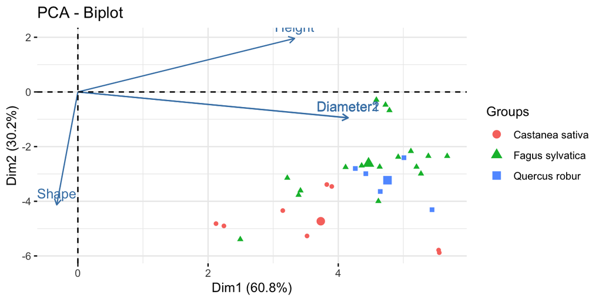

```r
fviz_pca_biplot(fit, label="var", habillage=FI_Murcia_sub$Species,
                select.ind = list(contrib = 30))
```

## Bubble charts

A bubble chart is basically just a scatterplot where the point size is proportional to the values of a third quantitative variable.

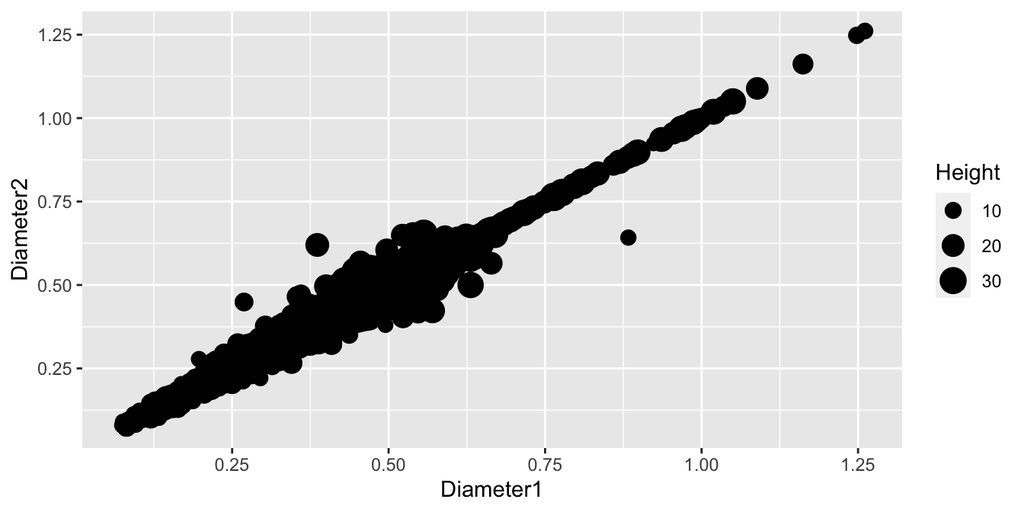

```r
ggplot(FI_Murcia_sub,
aes(x = Diameter1, y = Diameter2, size = Height)) + geom_point()
```

We can improve the default appearance by increasing the size of the bubbles, choosing a different point shape and color, and adding some transparency.

[figure not shown]

```r
ggplot(FI_Murcia_sub,
aes(x = Diameter1, y = Diameter2, size = Height)) +
  geom_point(alpha = .5, fill="cornflowerblue",
color="black", shape=21) + scale_size_continuous(range = c(1, 14)) +
labs(title = "Auto mileage by weight and horsepower",
size = "Height")
```

## Heatmaps

A heatmap displays a set of data using colored tiles for each variable value within each observation. There are many varieties of heatmaps.

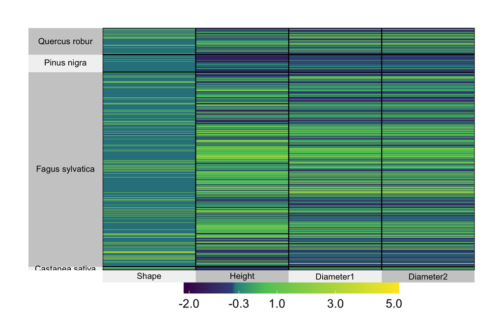

```r
library(superheat)
superheat(X = FI_Murcia_sub[,-c(1,6)],
  membership.rows = FI_Murcia_sub$Species, scale = TRUE,
  left.label.text.size=3, bottom.label.text.size=3,
  bottom.label.size = .05)
```

```r
library(curl)
Fires <- read.csv(curl("https://raw.githubusercontent.com/orrortega/statistics-natural-resources/main/data/Largest_fires_by_continent.csv"))
attach(Fires)
library(dplyr)
plotdata2 <- Fires %>%
  group_by(Region, year) %>%                            # multiple group columns
  summarise(total = sum(Size..km2.), na.rm = TRUE)
plotdata2$Region<-as.factor(plotdata2$Region)
library(reshape2)
plotdata2 <- dcast(plotdata2, Region~year, value.var = "total")
row.names(plotdata2)<- plotdata2$Region
plotdata2$Region<- NULL
sort.order <- order(plotdata2$"2016")
# color scheme
library(RColorBrewer)
colors <- rev(brewer.pal(5, "Blues"))
```

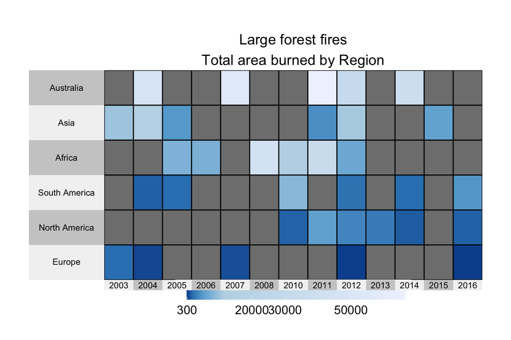

```r
superheat(plotdata2, scale = FALSE,
          left.label.text.size=3, bottom.label.text.size=3, bottom.label.size = .05,
          heat.pal = colors,
          order.rows = sort.order,
          title = "Large forest fires\nTotal area burned by Region")
```

## Scatterplot matrix

A scatterplot matrix is a collection of scatterplots organized as a grid. It is similar to a correlation plot but instead of displaying correlations, displays the underlying data. You can create a scatterplot matrix using the ggpairs function in the GGally package.

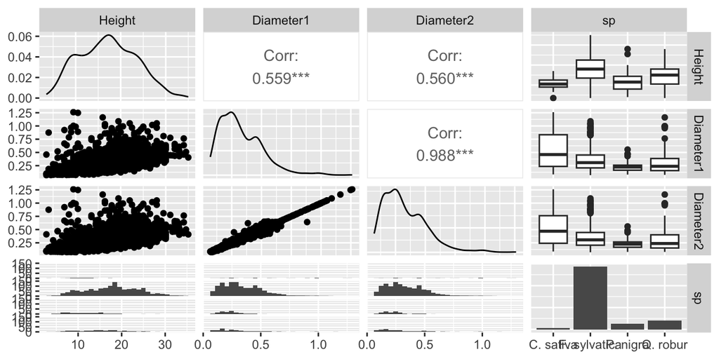

```r
FI_Murcia_sub$sp[FI_Murcia_sub$pcolor == "red"] <- "C. sativa"
FI_Murcia_sub$sp[FI_Murcia_sub$pcolor == "blue"] <- "Q. robur"
FI_Murcia_sub$sp[FI_Murcia_sub$pcolor == "green"] <- "F. sylvatica"
FI_Murcia_sub$sp[FI_Murcia_sub$pcolor == "yellow"] <- "P. nigra"
library(GGally)
ggpairs(FI_Murcia_sub[,-c(1,2,6)])
```